# Exploratory Data Analysis Using Random Forests

Zachary M. Jones and Fridolin Linder

2017-03-05

This package allows you to compute the partial dependence of covariates, compute permutation importance, and case/observation-level distance between data points given a fitted random forest from the following packages (outcome variable types supported in parenthesis): party (multivariate, regression, and classification), randomForestSRC (regression, classification), randomForest (regression and classification), and ranger (classification and regression).

The function `partial_dependence` outputs a `data.frame` of class `pd`. By default all of the supported random forest classifiers will return probabilities.

The `vars` argument is a character vector which gives the features for which the partial dependence is desired.

```r
library(edarf)

data(iris)
library(party)
fit <- cforest(Species ~ ., iris, controls = cforest_unbiased(mtry = 2))
pd <- partial_dependence(fit, vars = "Petal.Width", n = c(10, 25))
print(pd)
```

```
##    Petal.Width    setosa versicolor  virginica
## 1    0.1000000 0.6971284  0.2349063 0.06796526
## 2    0.3666667 0.6914523  0.2398904 0.06865734
## 3    0.6333333 0.3007795  0.5681631 0.13105747
## 4    0.9000000 0.3007795  0.5681631 0.13105747
## 5    1.1666667 0.2990429  0.5697648 0.13119223
## 6    1.4333333 0.3100852  0.5263477 0.16356711
## 7    1.7000000 0.3174794  0.1946512 0.48786943
## 8    1.9666667 0.3127924  0.1729954 0.51421220
## 9    2.2333333 0.3126790  0.1728630 0.51445792
## 10   2.5000000 0.3126790  0.1728630 0.51445792
```

The parameter `n` is a numeric vector of length two, which controls via its first element the size of the grid to evaluate the columns specified by the `vars` argument at, and the second element gives the number of rows of the other variables to sample when marginalizing the prediction function. All the actual computation is performed in the mmpf package using the function `marginalPrediction`. Additional arguments can be passed to this function by name (i.e., using `...`).

Output from `partial_dependence` can be visualized using `plot_pd`, which uses ggplot2 to create simple visualizations. In this simple case a line plot for each class.

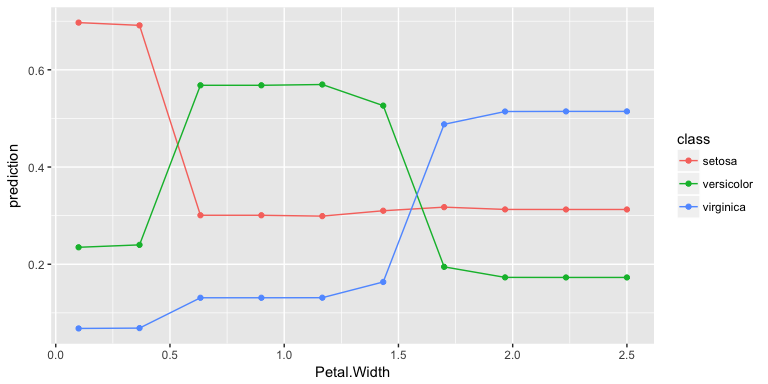

```r
plot_pd(pd)
```

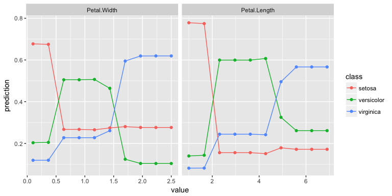

```r
pd_list <- partial_dependence(fit, c("Petal.Width", "Petal.Length"), n = c(10, 25), interaction = FALSE)
plot_pd(pd_list)
```

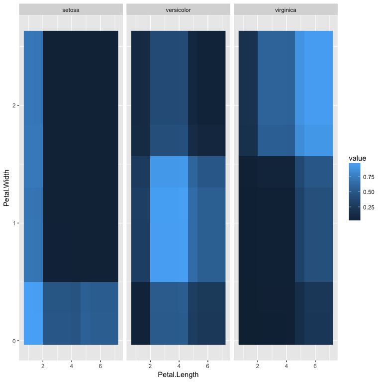

```r
pd_int <- partial_dependence(fit, c("Petal.Length", "Petal.Width"), n = c(10, 25), interaction = TRUE)
plot_pd(pd_int)
```

When an interaction is computed the `facet` argument is used to construct plots wheren the feature not set to be the facet is shown conditional on a particular value of the `facet` feature. This works best when said feature is an integer or a factor.

`variable_importance` can be used to compute the permutation importance of covariates. A particular covariate, or covariates, as specified by the `vars` parameter, are randomly shuffled, and predictions are computed. The aggregate permutation importance is the mean difference between the unpermuted predictions and the predictions made when the covariates specified in `vars` are permuted. If unspecified `vars` is set to all of the covariates used in the `fit`.

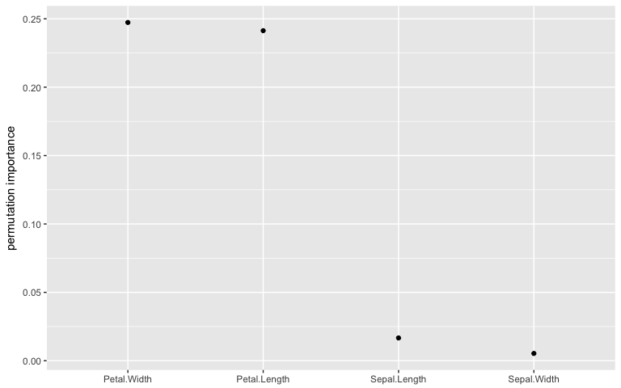

```r
imp <- variable_importance(fit, nperm = 10)
plot_imp(imp)
```

The joint permutation importance of multiple covariates can be computed by setting `interaction = TRUE`. `variable_importance` relies on `permutationImportance` in `mmpf` for computation, and additional arguments which allow the computation of local or class-specific importance, as well as the importance under arbitrary loss and contrast functions, can be passed by name to `permutationImportance`.

`extract_proximity` extracts or computes a matrix which gives the co-occurence of data points in the terminal nodes of the trees in the fitted random forest. This can be used to visualize the distance between data points in the model.

This matrix is too large to be visualized. `plot_prox` takes a principal components decomposition of this matrix using `prcomp`, and plots it using a biplot. Additional arguments allow other covariates to be mapped onto the size of the points, their color (shown), or their shape.

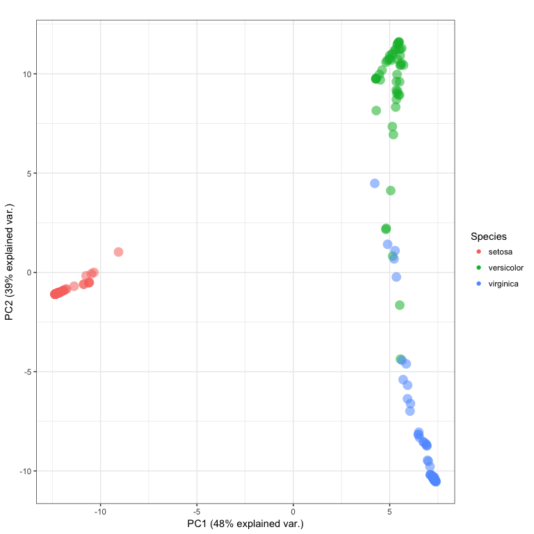

```r
fit <- cforest(Species ~ ., iris, control = cforest_unbiased(mtry = 2))
prox <- extract_proximity(fit)
pca <- prcomp(prox, scale = TRUE)
plot_prox(pca, color = iris$Species, color_label = "Species", size = 2)
```

The function `plot_pred` makes plots of predictions versus observations and has the additional feature of being able to “tag” outliers, and assign them labels.

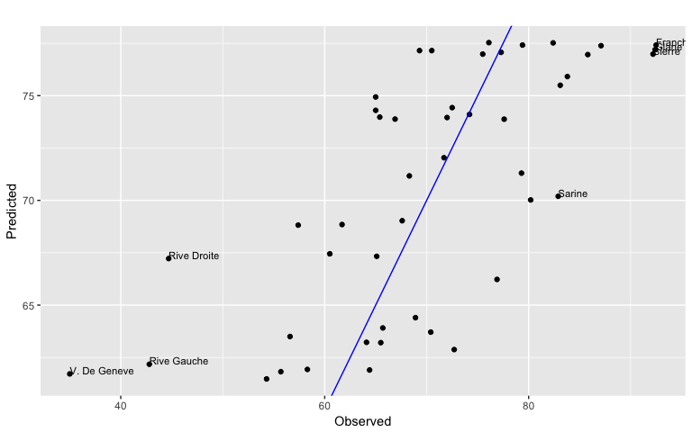

```r
fit <- cforest(Fertility ~ ., swiss)
pred <- as.numeric(predict(fit, newdata = swiss))
plot_pred(pred, swiss$Fertility,
  outlier_idx = which((pred - swiss$Fertility)^2 > var(swiss$Fertility)),
  labs = row.names(swiss))
```